# Coursera’s Reproducible Research Course Project 1

Norberto Hernandez

12/1/2021

# Introduction

According with the Coursera’s [Reproducible Research](https://www.coursera.org/learn/reproducible-research/home/welcome) “Course Project 1” now we have the possibility to reach a large amount of data about personal movement using activity monitoring devices.

These type of devices are part of a movement (who is called the **“quantified self”** movement) wants to take measurements about themselves regularly to:

- improve their health.
- find patterns in their behavior.
- curiosity (because they are tech geeks).

But these data remain under-utilized both because the raw data are hard to obtain and there is a lack of statistical methods and software for processing and interpreting the data.

This exercise will address this problem.

# Loading and preprocessing the data

## 1. Load the data

First, we load the libraries necessaries for the analisys.

```r
library(ggplot2)
```

Read the dataset from the web https://d396qusza40orc.cloudfront.net/repdata%2Fdata%2Factivity.zip. The file is a compressed .zip file, and the data is stored as a comma sepparated values (CSV).

```r
temp <- tempfile()
download.file("https://d396qusza40orc.cloudfront.net/repdata%2Fdata%2Factivity.zip",temp)
actdata <- read.csv(unz(temp, "activity.csv"), header = TRUE)
unlink(temp)
head(actdata)
```

```
##   steps       date interval
## 1    NA 2012-10-01        0
## 2    NA 2012-10-01        5
## 3    NA 2012-10-01       10
## 4    NA 2012-10-01       15
## 5    NA 2012-10-01       20
## 6    NA 2012-10-01       25
```

As we can notice, the dataset contains variables:

1. steps (the number of steps in a 5-minute interval).
2. date (the date of the register).
3. interval (the 5-minute interval measured by the activity device).

## Process/transform the data (if necessary) into a format suitable for your analysis

We notice that the variable `date` is a *character* type, so it will convert it into a *Date* type.

```r
class(actdata$steps)
```

```
## [1] "integer"
```

```r
class(actdata$date)
```

```
## [1] "character"
```

```r
class(actdata$interval)
```

```
## [1] "integer"
```

```r
actdata$date <- as.Date(as.character(actdata$date), format = "%Y-%m-%d")
class(actdata$date)
```

```
## [1] "Date"
```

# What is mean total number of steps taken per day?

For this part of the assignment, we do the following:

## Calculate the total number of steps taken per day

```r
stepdays <- tapply(actdata$steps, actdata$date, sum)
head(stepdays)
```

```
## 2012-10-01 2012-10-02 2012-10-03 2012-10-04 2012-10-05 2012-10-06
##         NA        126      11352      12116      13294      15420
```

## Make a histogram of the total number of steps taken each day

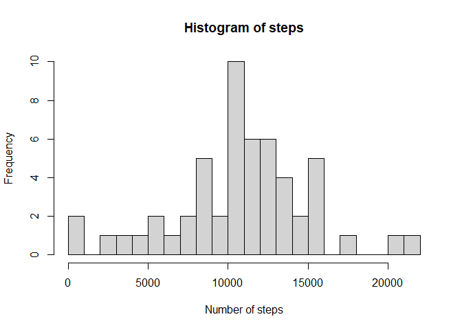

## Calculate and report the mean and median of the total number of steps taken per day

```r
mean(stepdays, na.rm = TRUE)
```

```
## [1] 10766.19
```

```r
median(stepdays, na.rm = TRUE)
```

```
## [1] 10765
```

As we can notice, mean and median of the total number of steps taken per day are around 10,765.

# What is the average daily activity pattern?

```r
daily <- tapply(actdata$steps, actdata$interval, mean, na.rm = TRUE)
summary(daily, na.rm = TRUE)
```

```
##    Min. 1st Qu.  Median    Mean 3rd Qu.    Max.
##   0.000   2.486  34.113  37.383  52.835 206.170
```

```r
head(daily)
```

```
##         0         5        10        15        20        25
## 1.7169811 0.3396226 0.1320755 0.1509434 0.0754717 2.0943396
```

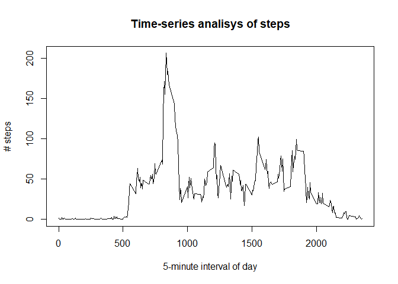